# 106休退學

第7組：蕭冠鈞、康暐郡、吳昱潔、高偉泰

2020/6/10

# 問題

- Q1.驗證報導真實性 新聞網址：https://www.chinatimes.com/realtimenews/20190402002327-260405?chdtv
- Q2.全國男和女的休學比例
- Q3.全國各校數學、物理系休學比例
- Q4.一般大學與技專校院休學率
- Q5.東部一般大學日間部退學率

# 動機

資料取得比較方便，再加上休退學率與我們切身相關

# Q1 驗證報導真實性

因為我們是從老師給的資訊查到這個新聞，理所當然我們就從這個新聞作為切入點，但我們直觀覺得此新聞給的結果怪怪的，所以我們深入去探討

新聞算法： 106休退學率

```
        = (106新增辦理休學人數+106休學而未復學人數+106退學人數) / 106在學學生數
        = (106休學人數+106退學人數) / 106在學學生數
        = (209392+91531) / 1273894
        = 300923 / 1273894
        ~ 0.23622
        ~ 25%
```

=> 幾乎每4個大專學生就有1人休退學

我們的算法： 106休退學率

```
        = (106休學人數+106退學人數) / (106休學人數+106退學人數+106在學學生數)
```

# Q1

106學年全國平均休退學率：

```
## [1] 0.1057245
```

106上學期休學率：

```
## [1] 0.07743033
```

106下學期休學率：

```
## [1] 0.07457125
```

106上學期休退學率：

```
## [1] 0.112513
```

106下學期休退學率：

```
## [1] 0.09883133
```

# Q2.全國男和女的休學比例

女性休學人數：

```
## [1] 90183
```

女性在學人數：

```
## [1] 1287966
```

男性休學人數：

```
## [1] 119189
```

男性在學人數：

```
## [1] 1257448
```

女性休學率=女性休學人數/(女性在學人數+女性休學人數)：

```
## [1] 0.06543777
```

男性休學率=男性休學人數/(男性在學人數+男性休學人數)：

```
## [1] 0.08657983
```

# Q2

男女休學率barplot：

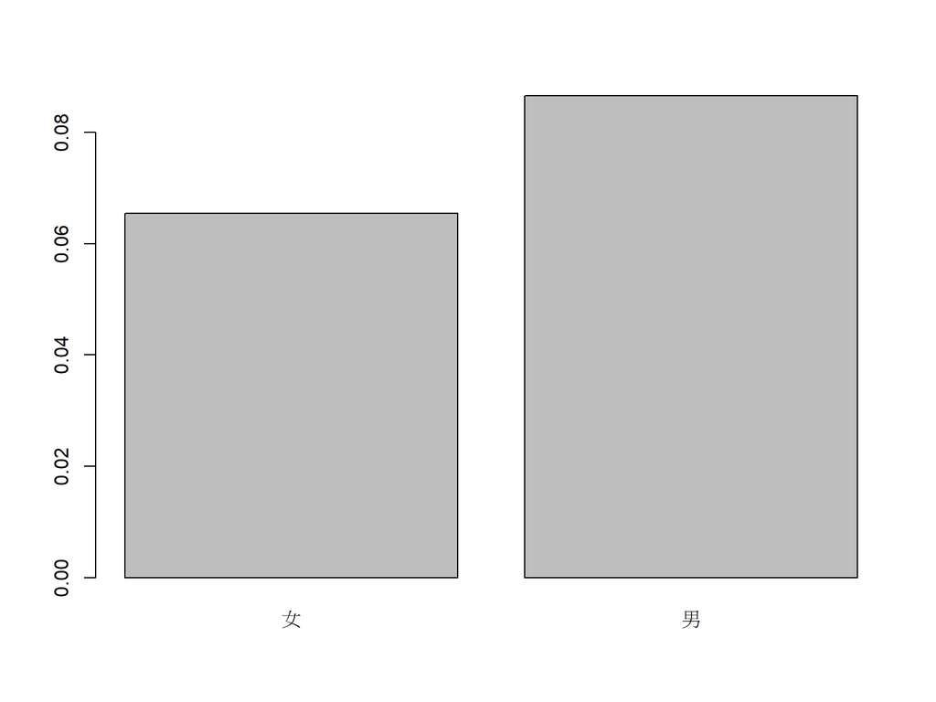

# Q2

男性最主要原因休學人數：

```
## [1] 31808
```

女性最主要原因休學人數：

```
## [1] 23468
```

# Q2

女性因工作休學率=女性工作休學人數/(女性休學人數+女性在學人數)：

```
## [1] 0.01702864
```

男性因工作休學率=男性工作休學人數/(男性休學人數+男性在學人數)：

```
## [1] 0.02310558
```

女性因志趣不合休學率=女性志趣不合休學人數/(女性休學人數+女性在學人數)：

```
## [1] 0.00899685
```

男性因志趣不合休學率=男性志趣不合休學人數/(男性休學人數+男性在學人數)：

```
## [1] 0.01064914
```

# Q2

女性因工作休學占女性休學人數的比例：

```
## [1] 0.2602264
```

男性因工作休學占男性休學人數的比例：

```
## [1] 0.2668703
```

女性因志趣不合休學占女性休學人數的比例：

```
## [1] 0.1374871
```

男性因志趣不合休學占男性休學人數的比例：

```
## [1] 0.1229979
```

# Q2

因志趣不合與工作的休學率比較圖

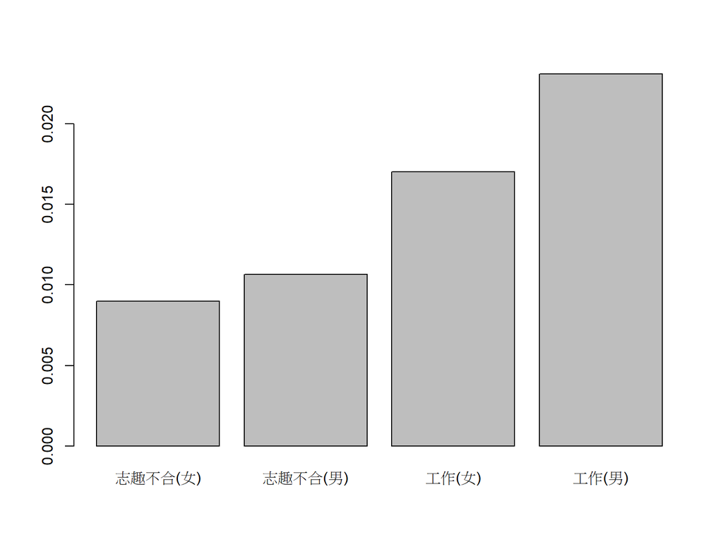

# Q3.全國各校數學、物理系休學比例

物理相關與數學相關休學人數boxplot：

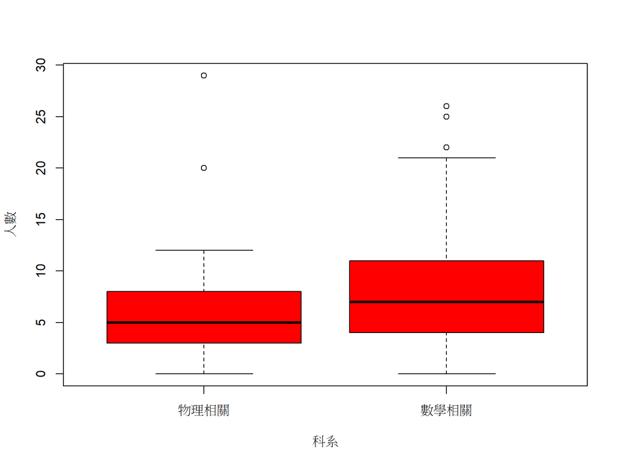

# Q3

台大休學率：

```
## [1] 0.04967624 0.03993567 0.05283856 0.03735555
```

休學率超過0.2的學校：

```
##      學年度 學期 設立別     學校類別 學校統計處代碼
## 1171    106    1   私立     一般大學           1079
## 1191    106    1   私立     技專校院           1081
## 1274    106    1   私立     技專校院           1183
## 1292    106    1   私立     技專校院           1188
## 1301    106    1   私立     技專校院           1192
## 1356    106    1   私立 宗教研修學院           1R03
## 2563    106    2   私立     技專校院           1081
## 2646    106    2   私立     技專校院           1183
## 2650    106    2   私立     技專校院           1183
## 2664    106    2   私立     技專校院           1188
## 2728    106    2   私立 宗教研修學院           1R03
##                          學校名稱     學制班別 性別 在學學生數
## 1171     康寧學校財團法人康寧大學 學士班(日間)   男        480
## 1191 東方學校財團法人東方設計大學 學士班(日間)   男        744
```

[output cut: 177 more lines]

# Q4.一般大學與技專校院休學率

科技大學的在學學生數與休學人數：

```
## [1] 1209820   97936
```

科技大學的休學率：

```
## [1] 0.07488859
```

一般大學的在學學生數與休學人數：

```
## [1] 1335000  111358
```

一般大學的休學率：

```
## [1] 0.076992
```

# Q5.東部一般大學日間部退學率

東部(含宜蘭)一般大學平均退學率：

```
## [1] 0.02354717
```

```
##    學年度 學期 設立別 學校類別                 學校名稱     學制班別 在學學生數
## 1     106    1   公立 一般大學             國立宜蘭大學 學士班(日間)       4450
## 2     106    1   公立 一般大學             國立東華大學 學士班(日間)       7659
## 3     106    1   公立 一般大學             國立臺東大學 學士班(日間)       3526
## 4     106    1   私立 一般大學 慈濟學校財團法人慈濟大學 學士班(日間)       2963
## 5     106    1   私立 一般大學                 佛光大學 學士班(日間)       3050
## 6     106    2   公立 一般大學             國立宜蘭大學 學士班(日間)       4550
## 7     106    2   公立 一般大學             國立東華大學 學士班(日間)       7659
## 8     106    2   公立 一般大學             國立臺東大學 學士班(日間)       3464
## 9     106    2   私立 一般大學 慈濟學校財團法人慈濟大學 學士班(日間)       2963
## 10    106    2   私立 一般大學                 佛光大學 學士班(日間)       3050
##    退學人數小計 eastquitrate
## 1           107  0.023480360
## 2           177  0.022588055
## 3           128  0.035030104
## 4           119  0.038611291
## 5           144  0.045084534
## 6            91  0.019607843
## 7            76  0.009825469
## 8            58  0.016467916
## 9            62  0.020495868
## 10           83  0.026492180
```

各學期退學率最高的學校：

```
## [1] "佛光大學"
```

```
## [1] "佛光大學"
```

# Data: Source

資料來源：教育部大專校院校務資訊公開平臺https://udb.moe.edu.tw/